# Lab 2: Sentiment Analysis I

Sofia Ingersoll

2024-04-10

## Assignment (Due 4/16 by 11:59 PM)

### Obtain your data and load it into R

- Access the Nexis Uni database through the UCSB library: https://www.library.ucsb.edu/research/db/211
- Choose a key search term or terms to define a set of articles.
- Use your search term along with appropriate filters to obtain and download a batch of at least 100 full text search results (.docx). You are limited to downloading 100 articles at a time, so if you have more results than that, you have to download them in batches (rows 1-100, 101-200, 201-300 etc.)

  Guidance for {LexisNexisTools} : https://github.com/JBGruber/LexisNexisTools/wiki/Downloading-Files-From-Nexis
- Read your Nexis article documents into RStudio.
- Use the full text of the articles for the analysis. Inspect the data (in particular the full-text article data).
- If necessary, clean any artifacts of the data collection process (hint: this type of thing should be removed: “Apr 04, 2022( Biofuels Digest: http://www.biofuelsdigest.com/Delivered by Newstex”) and any other urls)
- Remove any clear duplicate articles. LNT has a method for this, but it doesn’t seem to work, so you probably need to do it manually.

### Explore your data and conduct the following analyses:

### Load Articles

```r
# List all .docx files in the directory
post_files <- list.files(pattern = ".docx",
                         full.names = TRUE,
                         recursive = TRUE,
                         ignore.case = TRUE)

# Print the first few file paths to verify
#head(post_files)
```

```r
dat <- lnt_read(post_files)

# pull out respective table slots
meta_df <- dat@meta
articles_df <- dat@articles
paragraphs_df <- dat@paragraphs

dat2 <- tibble(
 id = articles_df$ID,
 date = meta_df$Date,
 headline = meta_df$Headline,
 text = articles_df$Article
)
```

### Article Inspection & Wrangling

The date is not being read in properly, so we’re going to wrangle the lnt object. Upon reflection of the documents I’ve downloaded, they all contain unique date patterns as a result of the different document types. Some examples include:

`Summer, 2012` `September 24, 2021` `January/February, 2023` `2021` `November, 2022`

Here we see that the dates are being stored in `Newspaper` column in an usual pattern.

```r
head(meta_df,3) %>%
  gt()
```

| ID | Source_File | Newspaper | Date | Length | Section | Author | Edition | Headline | Graphic |
| --- | --- | --- | --- | --- | --- | --- | --- | --- | --- |
| 1 | ./ARTICLE & COMMENT_ THE MEME STOCK BIDDING WAR VIEWED FROM THE LENSES OF THE AMERICAN AND CANADIAN SE.docx | Summer, 2023 | NA | 17245 words | NA | Boutros Imad* | NA | ARTICLE & COMMENT: THE MEME STOCK BIDDING WAR VIEWED FROM THE LENSES OF THE AMERICAN AND CANADIAN SECURITIES REGULATORS | FALSE |
| 2 | ./ARTICLE_ ADDRESSING BIG TECH'S MARKET POWER_ A COMPARATIVE INSTITUTIONAL ANALYSIS.docx | Winter, 2022 | NA | 50227 words | NA | Thomas A. Lambert* | NA | ARTICLE: ADDRESSING BIG TECH'S MARKET POWER: A COMPARATIVE INSTITUTIONAL ANALYSIS | FALSE |
| 3 | ./ARTICLE_ ALGORITHMIC COMPETITION, TRADE AND INVESTMENT_ THE CFIUS AS PRIVACY REGULATOR.docx | NA | NA | NA | NA | NA | NA | NA | TRUE |

```r
# Extract year from the date column using parse_date_time
meta_df$year <- year(parse_date_time(meta_df$Newspaper, orders = c("mdy", "dmy", "ymd", "my", "dm", "md", "y", "m", "d")))


# pull date info from true column & store year
dat2 <- tibble(
  id = articles_df$ID,
  date = meta_df$Newspaper,
  headline = meta_df$Headline,
  text = articles_df$Article,
  year = meta_df$year
)

unique(dat2$year)
```

```
##  [1] 2023 2022   NA 2021 2020 2024 1986 1994 2002 2015 2016 2004 2010 2012
```

```r
# this is the easiest format to scan the first few lines of each article in Article
head(dat2, 1) %>%
  gt()
```

| id | date | headline | text | year |
| --- | --- | --- | --- | --- |
| 1 | Summer, 2023 | ARTICLE & COMMENT: THE MEME STOCK BIDDING WAR VIEWED FROM THE LENSES OF THE AMERICAN AND CANADIAN SECURITIES REGULATORS | [*194] I. INTRODUCTION Online trading has significantly increased during the past several years due in large part to the pandemic and federal paychecks.2 Mobile apps and social media paved the way for… | 2023 |

```r
# make sure we don't have any duplicate articles
#length(unique(articles_df$Article))
```

I tried using regex to remove the word “INTRODUCTION” from the beginning of text entries, but couldn’t for now.

```r
# this chunk was unsuccessful, leaving for now
# Clean up the 'headline' and 'text' columns in dat2
cleaned_dat2 <- dat2 %>%
  # Remove starting words from 'text' column
 # mutate(text = gsub("^\\s*(INTRODUCTION):?\\s*", "", text, ignore.case = TRUE))
 # mutate(text = gsub("^\\s*(INTRODUCTION):?\\s*", "", text, ignore.case = TRUE))
  mutate(text = gsub("^\\s*(INTRODUCTION):?\\s*", "", text, ignore.case = TRUE))


head(cleaned_dat2, 1) %>%
  gt()
```

[output not shown]

1. Calculate mean sentiment across all your articles

```r
#load the bing sentiment lexicon from tidytext
bing_sent <-  get_sentiments("bing")
```

```r
text_words <- dat2 %>%
  unnest_tokens(output = word,
                # from the datafrane
                input = text,
                token = "words"
                )

#text_words

#Let's start with a simple numerical score
sent_words <- text_words %>%
  # remove stopwords at token level
  anti_join(stop_words, by ="word") %>%
  # apply scorees
  inner_join(bing_sent, by = "word") %>%
  # create numerical variable
  mutate(sent_num = case_when(
    sentiment == "negative" ~ -1,
    sentiment == "positive" ~ 1
  )
  )

head(sent_words, 6) %>%
  gt()
```

| id | date | headline | year | word | sentiment | sent_num |
| --- | --- | --- | --- | --- | --- | --- |
| 1 | Summer, 2023 | ARTICLE & COMMENT: THE MEME STOCK BIDDING WAR VIEWED FROM THE LENSES OF THE AMERICAN AND CANADIAN SECURITIES REGULATORS | 2023 | easy | positive | 1 |
| 1 | Summer, 2023 | ARTICLE & COMMENT: THE MEME STOCK BIDDING WAR VIEWED FROM THE LENSES OF THE AMERICAN AND CANADIAN SECURITIES REGULATORS | 2023 | free | positive | 1 |
| 1 | Summer, 2023 | ARTICLE & COMMENT: THE MEME STOCK BIDDING WAR VIEWED FROM THE LENSES OF THE AMERICAN AND CANADIAN SECURITIES REGULATORS | 2023 | fool | negative | -1 |
| 1 | Summer, 2023 | ARTICLE & COMMENT: THE MEME STOCK BIDDING WAR VIEWED FROM THE LENSES OF THE AMERICAN AND CANADIAN SECURITIES REGULATORS | 2023 | death | negative | -1 |
| 1 | Summer, 2023 | ARTICLE & COMMENT: THE MEME STOCK BIDDING WAR VIEWED FROM THE LENSES OF THE AMERICAN AND CANADIAN SECURITIES REGULATORS | 2023 | volatility | negative | -1 |
| 1 | Summer, 2023 | ARTICLE & COMMENT: THE MEME STOCK BIDDING WAR VIEWED FROM THE LENSES OF THE AMERICAN AND CANADIAN SECURITIES REGULATORS | 2023 | notorious | negative | -1 |

```r
# overall sentiment
sent_article <- sent_words %>%
  group_by(headline) %>%
  count(id, sentiment) %>%
  pivot_wider(names_from = sentiment,
             values_from = n) %>%
  mutate(polarity = positive-negative)

mean(sent_article$polarity, na.rm = TRUE)
```

```
## [1] -58.74747
```

```r
# individual article scores
sent_articles <- sent_words %>%
  group_by(headline) %>%
  summarize(avg_sentiment = mean(sent_num))


head(sent_articles, 6) %>%
  gt()
```

| headline | avg_sentiment |
| --- | --- |
| ARTICLE & COMMENT: THE MEME STOCK BIDDING WAR VIEWED FROM THE LENSES OF THE AMERICAN AND CANADIAN SECURITIES REGULATORS | -0.34280639 |
| ARTICLE: UNITED SKATES: A CALL FOR LEISURE JUSTICE FOR BLACK URBAN ADULT ROLLER SKATERS | -0.02904564 |
| ARTICLE: COMRADES OR FOES: DID THE CHINESE BREAK THE LAW OR NEW GROUND FOR THE FIRST AMENDMENT? | -0.12964824 |
| ARTICLE: Revisiting Indecency: Considering a Medium-Specific Regulatory Approach to Disinformation and Hate Speech on Social Media | -0.41843972 |
| ARTICLE: Rules of Engagement: Copyright and Automated Gatekeepers' Influence on Creative Expression | 0.26808511 |
| ARTICLE: TRANSATLANTIC DATA TRANSFER COMPLIANCE | 0.39325843 |

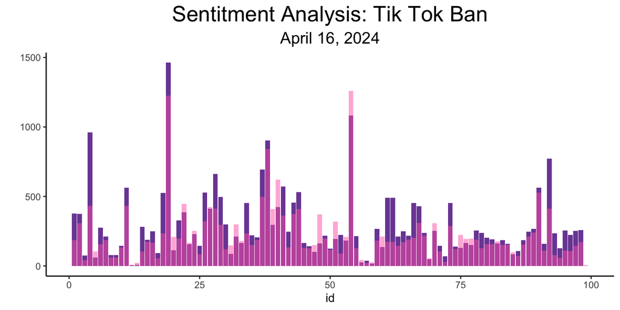

```r
ggplot(sent_article, aes(id)) +

  geom_col(aes(y = negative),
           stat = 'identity',
           fill = "purple4",
           alpha = 0.8) +

  geom_col(aes(y = positive),
           stat = 'identity',
           fill = "hotpink",
           alpha = 0.5) +

  labs(title = "Sentitment Analysis: Tik Tok Ban",
       subtitle = "April 16, 2024",
       y = " ") +

  theme_classic() +
  theme(
    plot.title = element_text(hjust = 0.5,
                              size = 20),

    plot.subtitle = element_text(hjust = 0.5,
                              size = 15),

    axis.title.x = element_text(hjust = 0.5)
  )
```

3. Most common nrc emotion words and plot by emotion

```r
nrc_sent <- get_sentiments('nrc')

nrc_words_count <- text_words %>%
  anti_join(stop_words, by = "word") %>%
  inner_join(nrc_sent) %>%
  count(word, sentiment, sort = TRUE)

head(nrc_words_count, 6) %>%
  gt()
```

| word | sentiment | n |
| --- | --- | --- |
| law | trust | 2673 |
| court | anger | 2259 |
| court | anticipation | 2259 |
| court | fear | 2259 |
| content | joy | 1861 |
| content | positive | 1861 |

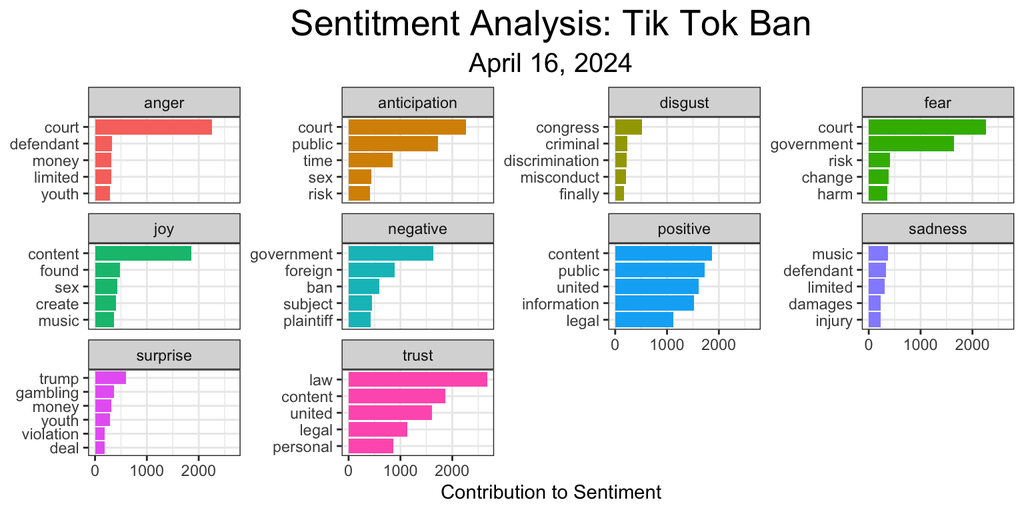

```r
sent_counts <- nrc_words_count %>%
  group_by(sentiment) %>%
  slice_max(n, n = 5) %>%
  ungroup() %>%
  # order from most to least frequent
  mutate(word = reorder(word, n))

ggplot(data = sent_counts,
       aes(x = n,
           y = word,
           fill = sentiment)) +

  geom_col(show.legend = FALSE) +

  facet_wrap(~sentiment, scales = "free_y") +

  labs(title = "Sentitment Analysis: Tik Tok Ban",
       subtitle = "April 16, 2024",
       x = "Contribution to Sentiment",
       y = NULL) +

  theme_bw() +
  theme(
    plot.title = element_text(hjust = 0.5,
                              size = 20),

    plot.subtitle = element_text(hjust = 0.5,
                              size = 15),

    axis.title.x = element_text(hjust = 0.5)
  )
```

```r
#plot sent_counts
sent_counts
```

```
## # A tibble: 51 × 3
##    word      sentiment        n
##    <fct>     <chr>        <int>
##  1 court     anger         2259
##  2 defendant anger          330
##  3 money     anger          317
##  4 limited   anger          312
##  5 youth     anger          295
##  6 court     anticipation  2259
##  7 public    anticipation  1727
##  8 time      anticipation   850
##  9 sex       anticipation   435
## 10 risk      anticipation   414
## # ℹ 41 more rows
```

4. Look at the nrc contribution to emotion by word plots. Identify and reclassify or remove at least one term that gives misleading results in your context.

We’re getting rid of `sex` because I don’t feel like it’s super imperative in the context of tik tok ban sentiments `joy` and `anticpation`.

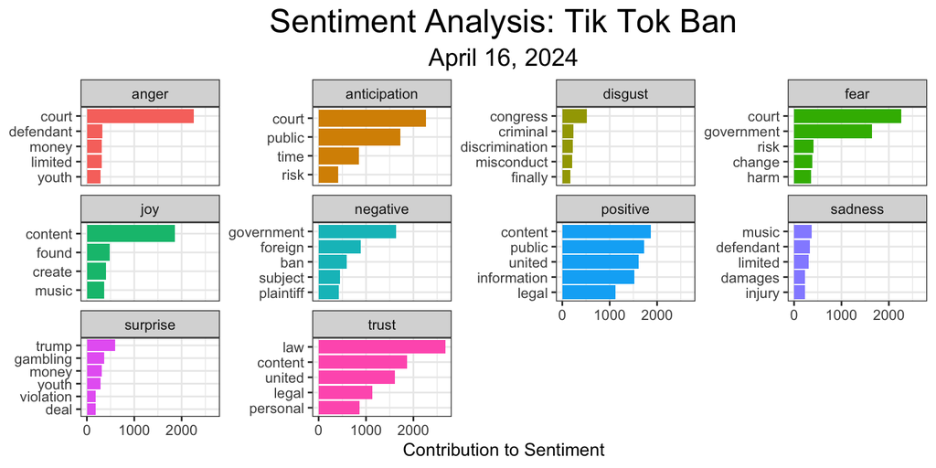

```r
# Alternatively, remove misleading words altogether
# List of words to remove from the analysis
words_to_remove <- c("sex")

# Remove rows containing the misleading words
sent_counts <- sent_counts[!sent_counts$word %in% words_to_remove, ]


# Create bar plot
ggplot(sent_counts, aes(x = n, y = word, fill = sentiment)) +
  geom_col(show.legend = FALSE) +
  facet_wrap(~sentiment, scales = "free_y") +
  labs(title = "Sentiment Analysis: Tik Tok Ban",
       subtitle = "April 16, 2024",
       x = "Contribution to Sentiment",
       y = NULL) +
  theme_bw()+
  theme(
    plot.title = element_text(hjust = 0.5,
                              size = 20),

    plot.subtitle = element_text(hjust = 0.5,
                              size = 15),

    axis.title.x = element_text(hjust = 0.5)
  )
```

5. Plot the amount of nrc emotion words as a percentage of all the emotion words used each day (aggregate text from articles published on the same day). How does the distribution of emotion words change over time? Can you think of any reason this would be the case?

So this is actually impossible for the data that I’m working with. To follow the request as closely as possible, I am aggregating by year and removing the years that fall outside of expected publication dates.

As expected, a drastic influx of NRC words appeared during the years that tik tok become more prevelent and controversial in American media. I am surprised by the decrease in NRC word frequency in the most recent year because there are politicians currently at work trying to actively ban tik tok. I haven’t been able to keep super up to date, but if I rememeber correctly, there was something on their ballot for potentially banning tik tok in the next several months. I would expect more articles to include NRC because of this, but this could be a result of the distribution of years I’ve downloaded. The majority appear to be from the spiked years, so this is likely influencing the plot below and skewing the spike compared to 2023-2024.

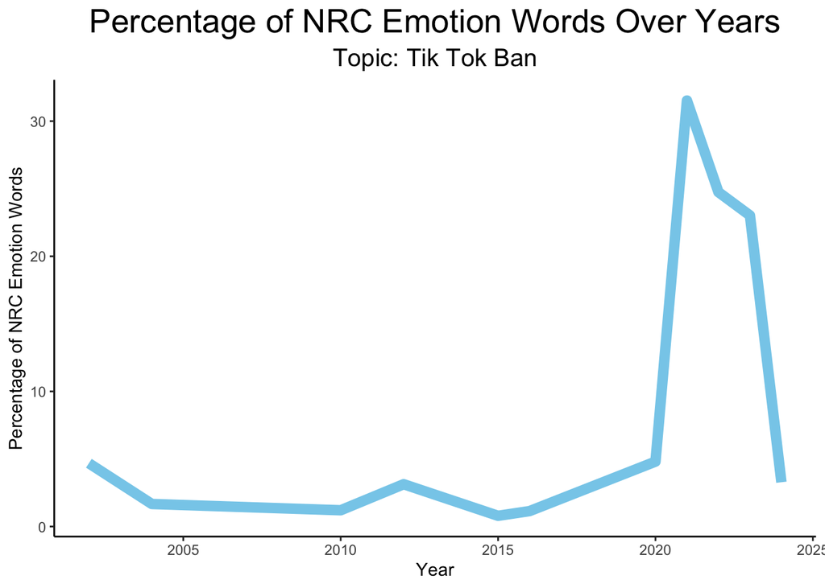

```r
# Aggregate text from articles published on the same year
dat2_grouped <- dat2 %>%
  # Remove years 1986 and 1994 because they're not related to today's tik tok
  filter(year != 1986 & year != 1994) %>%
  na.omit(year) %>%
  group_by(year) %>%
  summarise(agg_text = paste(text, collapse = " "))

# Tokenize the aggregated text
text_words <- dat2_grouped %>%
  unnest_tokens(output = word,
                input = agg_text,
                token = "words")

# Join with NRC sentiment lexicon
nrc_words_count <- text_words %>%
  anti_join(stop_words, by = "word") %>%
  inner_join(get_sentiments("nrc")) %>%
  count(year, sentiment, sort = TRUE)

# Calculate the percentage of NRC emotion words out of all emotion words used each year
nrc_percentage <- nrc_words_count %>%
  group_by(year) %>%
  summarise(nrc_count = sum(n)) %>%
  left_join(
    dat2_grouped %>% select(year),
    by = "year"
  ) %>%
  mutate(total_count = sum(nrc_count)) %>%
  mutate(percentage = (nrc_count / total_count) * 100)

# Plot the distribution of NRC emotion word percentage over time
ggplot(nrc_percentage, aes(x = year, y = percentage)) +
  geom_line(col = 'skyblue',
            size = 3) +
  labs(title = "Percentage of NRC Emotion Words Over Years",
       subtitle = "Topic: Tik Tok Ban",
       x = "Year",
       y = "Percentage of NRC Emotion Words") +
  theme_classic() +
  theme(
    plot.title = element_text(hjust = 0.5,
                              size = 20),

    plot.subtitle = element_text(hjust = 0.5,
                              size = 15)
  )
```